# HomeWork 1

Wesley Galvão

21/05/2020

### Questão 1

Faça algumas operações matemáticas com os operadores listados na aula 1. Escolha pelo menos três operadores distintos. Faça também 3 combinações distintas entre os operadores.

Os operadores são:

- Soma $+$
- Subtração $-$
- Divisão $/$
- Multiplicação $*$
- Exponenciação ^

```r
# Variáveis
a = 5
b = 7
c = 8.2
```

$\frac{(a + c) \times a}{b}$

```r
((a + c)*a)/b
```

```
## [1] 9.428571
```

$4.5 \times \frac{b}{a}$

```r
4.5*b/a
```

```
## [1] 6.3
```

$\frac{a^2 + b}{c} - 2 \times a$

```r
(a^2 + b)/c - 2*a
```

```
## [1] -6.097561
```

### Questão 2

Suponha que um pesquisador tenha criado o pacote chamado UFSCar. Que comando você utilizaria para instalar tal pacote? Que comando você utilizaria para carregar tal pacote? Suponha que dentro deste pacote UFSCar tenha a função Sorocaba. Como você acabou de instalar este pacote, ainda não está familiarizado com os termos desta nova função. Como você poderia descobrir como utilizar este comando dentro do R? E fora do R?(Você pode fazer uma pesquisa para responder essa questão).

- Para utilizar o pacote *UFSCar* basta instalá-lo e carregá-lo através dos respectivos comandos : `install.packages('UFSCar')` e `library(UFSCar)`.
- Uma vez que o pacote *UFSCar* esteja bem documentado, os usuários podem verificar o documento de utilização da função `sorocaba()` através dos comandos `?sorocaba` e `help(sorocaba)` no próprio console do R.
- Fora do R, a pesquisa a respeito do pacote e função pode ser feita no site oficial de documentações do R [R Documentation](https://www.rdocumentation.org) ou na comunidade [Stack Overflow](https://stackoverflow.com/).

### Questão 3

Como é possı́vel criar um chunk de código no R markdown? Quais as opções para usar knit? (Faça uma pesquisa para responder essa questão, ou use o card Rmarkdown disponibilizado no AVA).

- É possível inserir um *code chunk* por duas formas. Através do botão de insersão, com demonstrado na figura abaixo, ou pelo atalho de teclado `ctrl+shift+R`

[figure not shown]

How to insert a code chunck

- Para utilizar o *knit*, use botão *Knit* ilustrado na imagem acima ou o comando `render()`. Por padrão, o Rmarkdown pode ser renderizado para arquivos HTML, PDF e Word.

### Questão 4

Teste qual a diferença entre criar um vetor usando a função `c()` e `c("")`.

```r
# Crie os vetores
a = c(1,2,3)
b = c('1','2','3')
c = c(T,T,F)
d = c("1,2,3")

# Exiba o conteúdo de ambos os vetores
cat(" Conteúdo do vetor a: ", a)
```

```
##  Conteúdo do vetor a:  1 2 3
```

```r
cat("\n Conteúdo do vetor b: ", b)
```

```
##
##  Conteúdo do vetor b:  1 2 3
```

```r
cat("\n Conteúdo do vetor c: ", c)
```

```
##
##  Conteúdo do vetor c:  TRUE TRUE FALSE
```

```r
cat("\n Conteúdo do vetor d: ", d)
```

```
##
##  Conteúdo do vetor d:  1,2,3
```

```r
# Explore os tipos de dados
cat("\n \n Tipo de dado do vetor a: ", typeof(a))
```

```
##
##
##  Tipo de dado do vetor a:  double
```

```r
cat("\n Tipo de dado do vetor b: ", typeof(b))
```

```
##
##  Tipo de dado do vetor b:  character
```

```r
cat("\n Tipo de dado do vetor c: ", typeof(c))
```

```
##
##  Tipo de dado do vetor c:  logical
```

```r
cat("\n Tipo de dado do vetor d: ", typeof(d))
```

```
##
##  Tipo de dado do vetor d:  character
```

Enquanto a função `c()` pode criar vetores de diferentes tipos, onde os elementos são separados por vírgula, a função `c("")` cria vetores do tipo conjunto de caracteres, como demonstrado no vetor *d*. Ou seja, tudo o que estiver entre pararênteses é considerado carácter.

### Questão 5

Crie um vetor de todos números inteiros maiores do que 1 e menores do que 1000. Em seguida, crie um vetor com as mesmas caracterı́sticas, contudo apenas números pares. Dica: obviamente não espero que você digite elemento por elemento

- Vetor com inteiros maiores que 1 e menores que 1000

```r
a = c(2:999)
a
```

```
##   [1]   2   3   4   5   6   7   8   9  10  11  12  13  14  15  16  17  18  19
##  [19]  20  21  22  23  24  25  26  27  28  29  30  31  32  33  34  35  36  37
##  [37]  38  39  40  41  42  43  44  45  46  47  48  49  50  51  52  53  54  55
##  [55]  56  57  58  59  60  61  62  63  64  65  66  67  68  69  70  71  72  73
##  [73]  74  75  76  77  78  79  80  81  82  83  84  85  86  87  88  89  90  91
##  [91]  92  93  94  95  96  97  98  99 100 101 102 103 104 105 106 107 108 109
## [109] 110 111 112 113 114 115 116 117 118 119 120 121 122 123 124 125 126 127
## [127] 128 129 130 131 132 133 134 135 136 137 138 139 140 141 142 143 144 145
## [145] 146 147 148 149 150 151 152 153 154 155 156 157 158 159 160 161 162 163
## [163] 164 165 166 167 168 169 170 171 172 173 174 175 176 177 178 179 180 181
## [181] 182 183 184 185 186 187 188 189 190 191 192 193 194 195 196 197 198 199
## [199] 200 201 202 203 204 205 206 207 208 209 210 211 212 213 214 215 216 217
## [217] 218 219 220 221 222 223 224 225 226 227 228 229 230 231 232 233 234 235
## [235] 236 237 238 239 240 241 242 243 244 245 246 247 248 249 250 251 252 253
## [253] 254 255 256 257 258 259 260 261 262 263 264 265 266 267 268 269 270 271
```

[output cut: 41 more lines]

- Vetor com inteiros pares maiores que 1 e menores que 1000

```r
b = seq(from=2,to=999,by=2)
b
```

```
##   [1]   2   4   6   8  10  12  14  16  18  20  22  24  26  28  30  32  34  36
##  [19]  38  40  42  44  46  48  50  52  54  56  58  60  62  64  66  68  70  72
##  [37]  74  76  78  80  82  84  86  88  90  92  94  96  98 100 102 104 106 108
##  [55] 110 112 114 116 118 120 122 124 126 128 130 132 134 136 138 140 142 144
##  [73] 146 148 150 152 154 156 158 160 162 164 166 168 170 172 174 176 178 180
##  [91] 182 184 186 188 190 192 194 196 198 200 202 204 206 208 210 212 214 216
## [109] 218 220 222 224 226 228 230 232 234 236 238 240 242 244 246 248 250 252
## [127] 254 256 258 260 262 264 266 268 270 272 274 276 278 280 282 284 286 288
## [145] 290 292 294 296 298 300 302 304 306 308 310 312 314 316 318 320 322 324
## [163] 326 328 330 332 334 336 338 340 342 344 346 348 350 352 354 356 358 360
## [181] 362 364 366 368 370 372 374 376 378 380 382 384 386 388 390 392 394 396
## [199] 398 400 402 404 406 408 410 412 414 416 418 420 422 424 426 428 430 432
## [217] 434 436 438 440 442 444 446 448 450 452 454 456 458 460 462 464 466 468
## [235] 470 472 474 476 478 480 482 484 486 488 490 492 494 496 498 500 502 504
## [253] 506 508 510 512 514 516 518 520 522 524 526 528 530 532 534 536 538 540
## [271] 542 544 546 548 550 552 554 556 558 560 562 564 566 568 570 572 574 576
## [289] 578 580 582 584 586 588 590 592 594 596 598 600 602 604 606 608 610 612
## [307] 614 616 618 620 622 624 626 628 630 632 634 636 638 640 642 644 646 648
## [325] 650 652 654 656 658 660 662 664 666 668 670 672 674 676 678 680 682 684
## [343] 686 688 690 692 694 696 698 700 702 704 706 708 710 712 714 716 718 720
## [361] 722 724 726 728 730 732 734 736 738 740 742 744 746 748 750 752 754 756
## [379] 758 760 762 764 766 768 770 772 774 776 778 780 782 784 786 788 790 792
## [397] 794 796 798 800 802 804 806 808 810 812 814 816 818 820 822 824 826 828
## [415] 830 832 834 836 838 840 842 844 846 848 850 852 854 856 858 860 862 864
## [433] 866 868 870 872 874 876 878 880 882 884 886 888 890 892 894 896 898 900
## [451] 902 904 906 908 910 912 914 916 918 920 922 924 926 928 930 932 934 936
## [469] 938 940 942 944 946 948 950 952 954 956 958 960 962 964 966 968 970 972
## [487] 974 976 978 980 982 984 986 988 990 992 994 996 998
```

### Questão 6

Calcule o número de ouro no R.Resolução baseada no conteúdo do sites [R-Bloggers](https://www.r-bloggers.com/example-7-1-create-a-fibonacci-sequence/) e [InfoEscola](https://www.infoescola.com/matematica/numero-de-ouro/).

A proporção áurea é definida por $\phi=\frac{1+\sqrt{5}}{2}=1,6180339887...$. Assim:

```r
(1+sqrt(5)) / 2
```

```
## [1] 1.618034
```

```r
tam = 20 # Defina o tamanho da sequência
fib = numeric(tam) # Cria um vetor nulo de tamanho 10
fib[1] = 1
fib[2] = 1

for(i in 3 : tam)
  fib[i] = fib[i - 1] + fib[i - 2]

fib
```

```
##  [1]    1    1    2    3    5    8   13   21   34   55   89  144  233  377  610
## [16]  987 1597 2584 4181 6765
```

- Para encontrar a proporção áurea a partir da sequência fazemos a razão entre dois número consecutivos até um critério de parada, como a melhor aproximação:

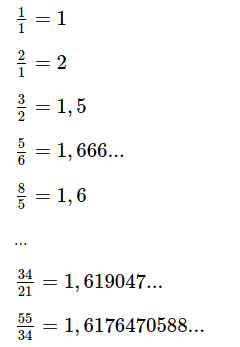

- Para calcular o número de ouro através da sequência encontrada, temos:

```r
golden = numeric(tam)
for(i in 3 : tam)
  golden[i] = abs(fib[i-1]/fib[i-2])
golden
```

```
##  [1] 0.000000 0.000000 1.000000 2.000000 1.500000 1.666667 1.600000 1.625000
##  [9] 1.615385 1.619048 1.617647 1.618182 1.617978 1.618056 1.618026 1.618037
## [17] 1.618033 1.618034 1.618034 1.618034
```

- Podemos extrair o último elemento do vetor que é o valor que mais se aproxima da definição. Então temos que o número áureo é dado por:

```r
golden[tam]
```

```
## [1] 1.618034
```

### Questão 7

Qual o resultado da divisão de 1 por 0 no R? E de -1 por 0?

```r
# Divisão de 1 por 0
cat("1/0: ", 1/0)
```

```
## 1/0:  Inf
```

```r
# Divisão de -1 por 0
cat("\n-1/0: ", -1/0)
```

```
##
## -1/0:  -Inf
```

O valor Inf significa infinito.

### Questão 8

Verifique quais as diferenças entre NaN, NULL, NA e Inf? Digite expressões que retornem cada um desses resultados.

- `NaN : Not a Number, ou seja, não definido com um número`

```r
0/0
```

```
## [1] NaN
```

- `NULL : Elemento nulo ou vazio`

```r
nulo = NULL
nulo
```

[output not shown]

- `NA : Elemento faltante, não existe`

```r
faltante = c(NA, 1:10)
faltante
```

```
##  [1] NA  1  2  3  4  5  6  7  8  9 10
```

- `Inf : infinito`

```r
1/0
```

```
## [1] Inf
```

### Questão 9

Verifique o que retorna a expressão `5 + 3 * 10 %/% 3 == 15` retorna no R. Faça a expressão retornar o valor contrário apenas usando parênteses - ou seja, se a expressão retornar originariamente TRUE, faça retornar FALSE. Explique o que faz a expressão original.

- O operador %/% retorna a divisão inteira entre dois operandos.

A expressão original retorna:

```r
5 + 3 * 10 %/% 3 == 15
```

```
## [1] FALSE
```

```r
(5 + (3 * 10)) %/% 3 == 15
```

```
## [1] FALSE
```